[O’Hara on GitHub](https://github.com/oharac)

# Map vulnerability by taxon (species mean)

Compiled on Sat Sep 16 19:33:31 2023 by ohara

```r
knitr::opts_chunk$set(echo = TRUE, message = FALSE, warning = FALSE, fig.height = 4, fig.width = 7)

library(terra)
library(oharac)
library(data.table)
library(tidyverse)
library(here)
source(here('common_fxns.R'))
```

# 1 Summary

Apply vulnerability scores to mapped species. Map out vulnerability to each stressor, first unweighted by species (each spp counts same, this script), then weighted by functional vulnerability (FEs with higher FV are given greater weight, next script). This script only includes species categorized into a functional entity.

# 2 Data

- AquaMaps and IUCN rangemaps
- Vulnerability Framework data for vulnerability scores
- FishBase/SeaLifeBase and vulnerability framework data for functional entity assignments

# 3 Methods

## 3.1 Set up dataframe of species

This includes information on species vulnerability scores, functional entity ID and traits, as well as which species are mapped in which sources (including rangemap filenames).

```r
spp_info_df <- get_spp_info() %>%
  rename(vulnerability = stressor)
```

## 3.2 Set up a function to process the various steps

```r
mc_process_vuln <- function(spp_maps_df, spp_str_info_df) {
    ### Break into chunks for parallel processing
    chunk_size <- 100000

    base_r   <- rast(here('_spatial/ocean_bc_1km.tif'))
    n_cells  <- ncell(base_r)
    n_chunks <- ceiling(n_cells/chunk_size)

    n_cores <- max(1, floor(8 / ceiling(nrow(spp_maps_df)/n_cells)))
    message('Using ', n_cores, ' cores for ', nrow(spp_maps_df), ' observations...')

    vuln <- spp_str_info_df$vulnerability %>% unique()
    taxon <- spp_str_info_df$taxon %>% unique()
    spp_vuln_df <- spp_str_info_df %>%
      select(species, v_score) %>%
      distinct()

    # system.time({
    result_list <- parallel::mclapply(1:n_chunks, mc.cores = n_cores,
       FUN = function(n) { ### n <- 6
         cell_id_min <- as.integer((n - 1) * chunk_size + 1)
         cell_id_max <- as.integer(n * chunk_size)
         message('Summarizing vuln to ', vuln, ' on ',
                 taxon, ': chunk ', n, ' of ', n_chunks, '...')

         ### filter to chunk cells and join vulnerability scores
         chunk_spp_cells <- spp_maps_df %>%
           filter(between(cell_id, cell_id_min, cell_id_max)) %>%
           oharac::dt_join(spp_vuln_df, by = 'species', type = 'left')

         ### summarize unweighted mean/sdev
         chunk_sum_unwt <- chunk_spp_cells %>%
           data.table() %>%
           .[, .(vuln_mean_unwt = mean(v_score),
                 vuln_sd_unwt   = sd(v_score),
                 n_spp          = length(unique(species))),
             by = .(cell_id)]
         return(chunk_sum_unwt)
         })

    if(check_tryerror(result_list)) {
      stop('Try error results in mc_process_vuln for vuln ', vuln, '...')
    }

    message('Binding cell results for vuln ', vuln, '...')
    result_df <- result_list %>%
      data.table::rbindlist() %>%
      filter(!is.na(cell_id))
}
```

## 3.3 Loop over taxon and vulnerability

```r
taxa_vec <- spp_info_df$taxon %>% unique() %>% sort()

### limit vulnerability maps to just those with stressor maps
# vuln_vec <- spp_info_df$vulnerability %>% unique()
vuln_vec <- read_csv(here('_raw/stressor_vulnerability_lookup.csv')) %>%
  pull(vulnerability) %>%
  unique() %>% sort()

spp_info_df %>%
  select(species, taxon) %>%
  distinct() %>% pull(taxon) %>% table()
```

```
## .
##          cephalopods               corals crustacea_arthropods
##                   15                   44                  166
##          echinoderms        elasmobranchs                 fish
##                  126                   28                  598
##       marine_mammals             molluscs          polychaetes
##                   38                   95                  133
##             reptiles             seabirds              sponges
##                    1                   65                   17
```

```r
### Loop over taxa levels
for(t in taxa_vec) {
  ### t <- taxa_vec[1]
  tx_spp <- spp_info_df %>%
    filter(taxon == t)
  tx_map_df <- tx_spp %>%
    select(species, map_f) %>%
    distinct()

  message('Processing impacts for ', t, '...')

  ### if it exists, spp_maps_df is from a different taxon...
  ### remove it here; and if any vulns need to be processed, load
  ### it inside the vuln loop...
  if(exists('spp_maps_df')) rm('spp_maps_df')

  ### Loop over vulns
  for(v in vuln_vec) { ### v <- vuln_vec[1]
    prms <- c('mean', 'sdev', 'nspp')
    outfile_stem <- here_anx('vuln_maps_by_taxon/vuln_by_species/vuln_%s_%s_spp_%s.tif')
      ### vuln, taxon, parameter
    outfiles <- sprintf(outfile_stem, v, t, prms) %>%
      setNames(prms)
    ### unlink(outfiles)
    if(all(file.exists(outfiles[c('mean', 'sdev')]))) {
      ### nspp rasts are collected into a single one later in the script;
      ### don't recreate those if the other two exist!
      message('All files exist for vulnerability ', v, ' on ', t, '...')
      next()
    }

    message('Processing vulnerability ', v, ' on ', t, '...')

    ### If not yet loaded for this taxon, load spp maps
    if(!exists('spp_maps_df')) {
      message('Loading species rangemaps for ', t, '...')

      spp_maps_df <- collect_spp_rangemaps(spp_vec  = tx_map_df$species,
                                           file_vec = tx_map_df$map_f,
                                           parallel = TRUE)
        # spp_maps_df <- spp_maps_raw %>%
        #   calc_spp_cell_fv(spp_fe)
    }

    ### grab vulnerability scores for this stressor/taxon combo and process maps
    spp_str_info_df <- tx_spp %>%
      filter(vulnerability == v)

    str_vuln_map_df <- mc_process_vuln(spp_maps_df, spp_str_info_df)

    message('Creating and saving unweighted mean vuln rasters for ',
            v, ' on ', t, '...')
    rast_mean_unwt <- map_to_bc(str_vuln_map_df, which = 'vuln_mean_unwt')
    rast_sd_unwt   <- map_to_bc(str_vuln_map_df, which = 'vuln_sd_unwt')
    rast_nspp      <- map_to_bc(str_vuln_map_df, which = 'n_spp')

    writeRaster(rast_mean_unwt, outfiles['mean'], overwrite = TRUE)
    writeRaster(rast_sd_unwt,   outfiles['sdev'], overwrite = TRUE)
    writeRaster(rast_nspp,      outfiles['nspp'], overwrite = TRUE)
  }
}
```

## 3.4 Aggregate taxon vuln maps to all species

For each vuln, pull in all taxon rasters, assemble into dataframe, and summarize to aggregate mean, sd, and nspp. This will require a pooled variance approach to backing out the standard deviation.

Pooled variance formula when variances not necessarily equal (from one of the responses [here](https://math.stackexchange.com/questions/2971315/how-do-i-combine-standard-deviations-of-two-groups))

$$s^2_{x_1 \cup x_2} =
\frac{(n_1-1)s^2_{x_1} + (n_2-1)s^2_{x_2}}{(n_1+n_2-1)} +
\frac{n_1 n_2(\bar x_1 - \bar x_2)^2}{(n_1+n_2)(n_1+n_2-1)}$$

```r
combine_taxa_maps <- function(str_tx_v_df) {

  vuln <- str_tx_v_df$v %>% unique()

  mean_fs <- str_tx_v_df %>% filter(p == 'mean')
  sdev_fs <- str_tx_v_df %>% filter(p == 'sdev')
  nspp_fs <- str_tx_v_df %>% filter(p == 'nspp')

  message('... loading mean maps across all taxa for vuln ', vuln, '...')
  mean_df <- parallel::mclapply(mean_fs$f, mc.cores = 16, FUN = r_to_df) %>%
    setNames(mean_fs$t) %>%
    data.table::rbindlist(idcol = 'taxon') %>%
    rename(v_mean = val)

  message('... loading std dev maps across all taxa for vuln ', vuln, '...')
  sdev_df <- parallel::mclapply(sdev_fs$f, mc.cores = 16, FUN = r_to_df) %>%
    setNames(sdev_fs$t) %>%
    data.table::rbindlist(idcol = 'taxon') %>%
    rename(v_sdev = val)

  message('... loading nspp maps across all taxa for vuln ', vuln, '...')
  nspp_df <- parallel::mclapply(nspp_fs$f, mc.cores = 16, FUN = r_to_df) %>%
    setNames(nspp_fs$t) %>%
    data.table::rbindlist(idcol = 'taxon') %>%
    rename(v_nspp = val)

  message('... joining mean, sd, nspp into big-ass dataframe for vuln ', vuln, '...')
  big_df <- mean_df %>%
    oharac::dt_join(sdev_df, by = c('taxon', 'cell_id'), type = 'full') %>%
    oharac::dt_join(nspp_df, by = c('taxon', 'cell_id'), type = 'full')

  return(big_df)
}

process_mean_rasts <- function(big_df) {
  ### Set up for parallel processing
  cell_id_vec <- big_df$cell_id %>% unique()
  n_gps <- 120
  gp_vec <- rep(1:n_gps, length.out = length(cell_id_vec))

  ### perform parallel processing
  spp_mean_list <- parallel::mclapply(
    X = 1:n_gps, mc.cores = 4,
    FUN = function(gp) { ### gp <- 1
      gp_cells <- cell_id_vec[gp_vec == gp]
      message('...processing ', length(gp_cells), ' cells in group ', gp, ' of ', n_gps, '...')

      gp_out <- big_df %>%
        data.table() %>%
        ### data.table filter:
        .[cell_id %in% gp_cells, ] %>%
        ### data.table summarize:
        .[, .(vuln_mean = sum(v_mean * v_nspp) / sum(v_nspp)),
          by = .(cell_id)]
    })

  ### gather results
  spp_mean_df <- data.table::rbindlist(spp_mean_list)
  return(spp_mean_df)
}

process_sdev_rasts <- function(big_df) {
  ### Set up for parallel processing
  cell_id_vec <- big_df$cell_id %>% unique()
  n_gps <- 200
  gp_vec <- rep(1:n_gps, length.out = length(cell_id_vec))

  ### perform parallel processing
  spp_sdev_list <- parallel::mclapply(
    X = 1:n_gps, mc.cores = 4,
    FUN = function(gp) { ### gp <- round(n_gps / 2)
      gp_cells <- cell_id_vec[gp_vec == gp]
      message('...processing ', length(gp_cells), ' cells in group ', gp,
              ' of ', n_gps, '...')

      gp_sdev_out <- big_df %>%
        data.table() %>%
        ### filter
        .[cell_id %in% gp_cells, ] %>%
        ### summarize
        .[, .(vuln_sdev = iterated_pooled_var(v_mean, v_sdev, v_nspp) %>% sqrt()),
          by = .(cell_id)]

      return(gp_sdev_out)
    })

  ### gather results
  spp_sdev <- data.table::rbindlist(spp_sdev_list)
  return(spp_sdev)
}

r_to_df <- function(f) {
  r <- terra::rast(f)
  df <- data.frame(values(r),
                   cell_id = 1:ncell(r)) %>%
    rename(val := !!names(r)) %>%
    filter(!is.na(val))
  return(df)
}
```

```r
taxon_map_dir <- here_anx('vuln_maps_by_taxon', 'vuln_by_species')
tx_v_map_df <- data.frame(f = list.files(taxon_map_dir, full.names = TRUE,
                                         pattern = 'vuln_.+.tif')) %>%
  mutate(t = str_extract(basename(f), paste0(taxa_vec, collapse = '|')),
         v = str_extract(basename(f), paste0(vuln_vec, collapse = '|')),
         p = str_extract(basename(f), '_mean|_sdev|_nspp') %>% str_remove('_'))

out_stem <- here_anx('_output/vuln_maps/vuln_maps_by_species/vuln_spp_%s_%s.tif')
  ### format will be: vuln, parameter (mean, sd, nspp)
# unlink(list.files(dirname(out_stem), full.names = TRUE))

for(vuln in vuln_vec) {
  ### vuln <- vuln_vec[1]

  ### check if total vuln maps are complete
  outf_mean <- sprintf(out_stem, vuln, 'mean')
  outf_sdev <- sprintf(out_stem, vuln, 'sdev')
  outf_nspp <- sprintf(out_stem, vuln, 'nspp')

  if(all(file.exists(outf_mean, outf_sdev))) {
    ### don't worry about testing for species richness files here...
    message('All summary rasters exist for vuln ', vuln, '... skipping!')
    next()
  }

  ### Combine mean, sdev, and nspp maps by taxon into one big dataframe
  message('Processing mean, sd, nspp maps across all species for ', vuln, '...')
  str_tx_v_df <- tx_v_map_df %>%
    filter(v == vuln)
  # asdf <- str_tx_v_df %>% filter(p == 'mean') %>% pull(f)
  # zxcv <- rast(asdf[6])
  # plot(zxcv)
  big_df <- combine_taxa_maps(str_tx_v_df)
  ### Process mean raster across taxa
  if(!file.exists(outf_mean)) {
    message('... summarizing mean vulnerability map across all taxa...')
    spp_mean <- process_mean_rasts(big_df)
    rast_mean <- map_to_bc(spp_mean, which = 'vuln_mean')
    writeRaster(rast_mean, outf_mean, overwrite = TRUE)
  } else {
    message('... mean vulnerability map exists for vuln ', vuln, '... skipping!')
  }

  ### Process standard deviation raster across taxa using pooled var
  if(!file.exists(outf_sdev)) {
    message('... summarizing standard deviation vulnerability map across all taxa...')
    spp_sdev <- process_sdev_rasts(big_df)
    rast_sdev <- map_to_bc(spp_sdev, which = 'vuln_sdev')
    writeRaster(rast_sdev, outf_sdev, overwrite = TRUE)
  } else {
    message('... standard deviation map exists for vuln ', vuln, '... skipping!')
  }

    ### Process species richness raster across taxa
  if(!file.exists(outf_nspp)) {
    message('... summarizing spp richness map across all taxa...')
    spp_nspp <- big_df %>%
      data.table() %>%
      .[, .(vuln_nspp = sum(v_nspp)),
        by = .(cell_id)]

    rast_nspp <- map_to_bc(spp_nspp, which = 'vuln_nspp')
    writeRaster(rast_nspp, outf_nspp, overwrite = TRUE)
  } else {
    message('... species richness map exists for vuln ', vuln, '... skipping!')
  }
}
```

### 3.4.1 Check species richness maps

These should all be the same. If so, copy one to the main output and delete the rest as redundant.

```r
nspp_main_out_f <- here('_output/nspp_maps/species_richness.tif')
nspp_vuln_fs <- list.files(dirname(out_stem), pattern = 'nspp.tif',
                           full.names = TRUE)

if(!file.exists(nspp_main_out_f)) {
  ### create the main spp richness raster from vuln-level richness rasters,
  ### which *should* all be identical.

  if(length(nspp_vuln_fs) < length(vuln_vec)) {
    stop('Species richness raster ', basename(nspp_main_out_f), ' is missing, but ',
         'not all vuln-level species richness maps are available!')
  }

  nspp_list <- lapply(nspp_vuln_fs, raster::raster)

  ### if not all equal, this throws an error - stop and figure out why
  check_nspp <- raster::compareRaster(nspp_list, values = TRUE, stopiffalse = TRUE)

  ### all are equal, so copy one to nspp_main_out_f and delete the vuln-level ones
  writeRaster(nspp_list[[1]], nspp_main_out_f, overwrite = TRUE)
  unlink(nspp_vuln_fs)

} else if(length(nspp_vuln_fs) > 0) {
  ### verify that the main out file is the same as any vuln-level ones
  nspp_main <- rast(nspp_main_out_f)
  nspp_list <- rast(nspp_vuln_fs)

  ### if not all equal, this throws an error - stop and figure out why
  check_nspp <- lapply(nspp_list,
                       FUN = function(r) {
                         raster::compareRaster(nspp_main, r,
                                               values = TRUE,
                                               stopiffalse = TRUE)
                       })
  if(!all(check_nspp)) stop('wtf, not all species richness rasters agree!')

  ### if all good, delete the vuln-level maps as redundant
  unlink(nspp_vuln_fs)

}
```

# 4 Results: Plot example maps

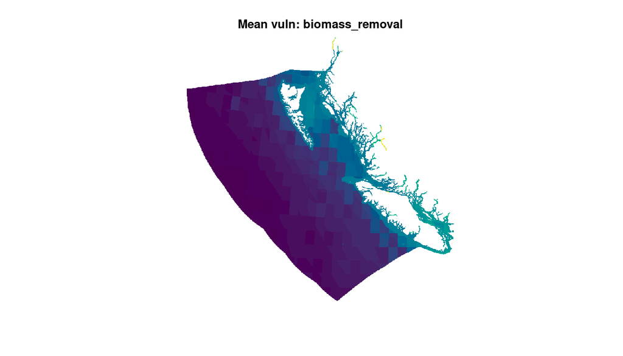

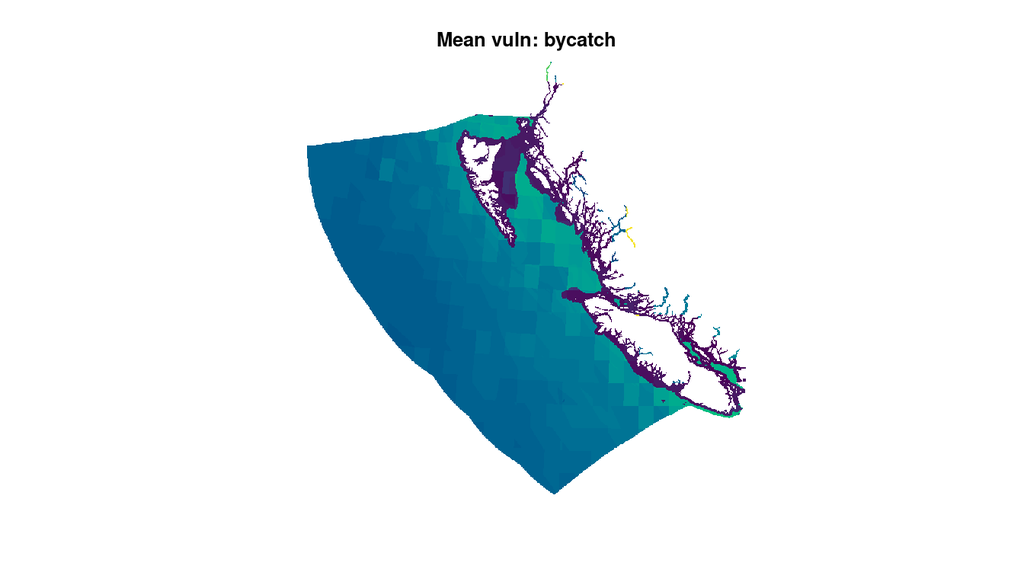

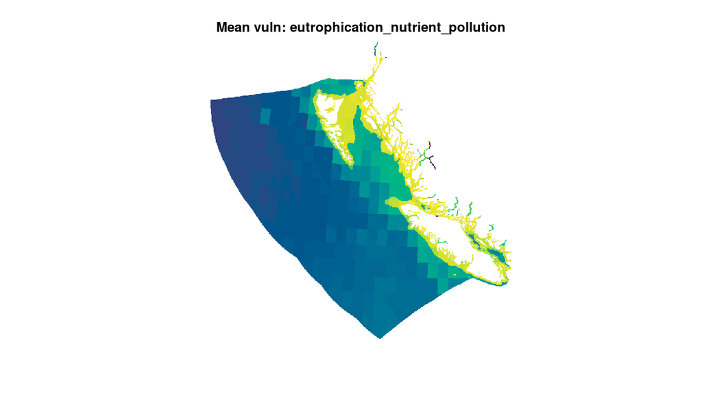

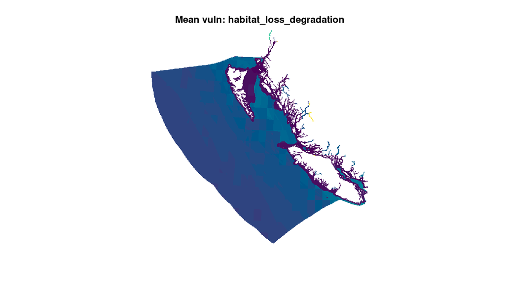

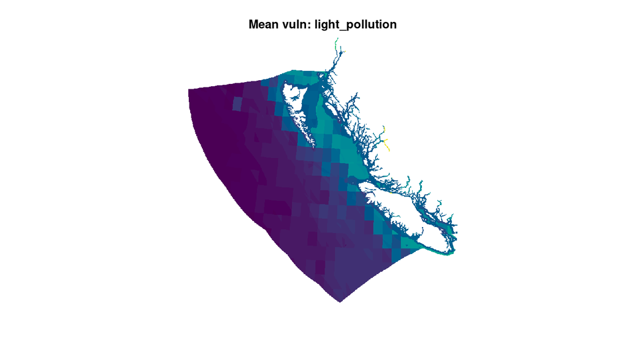

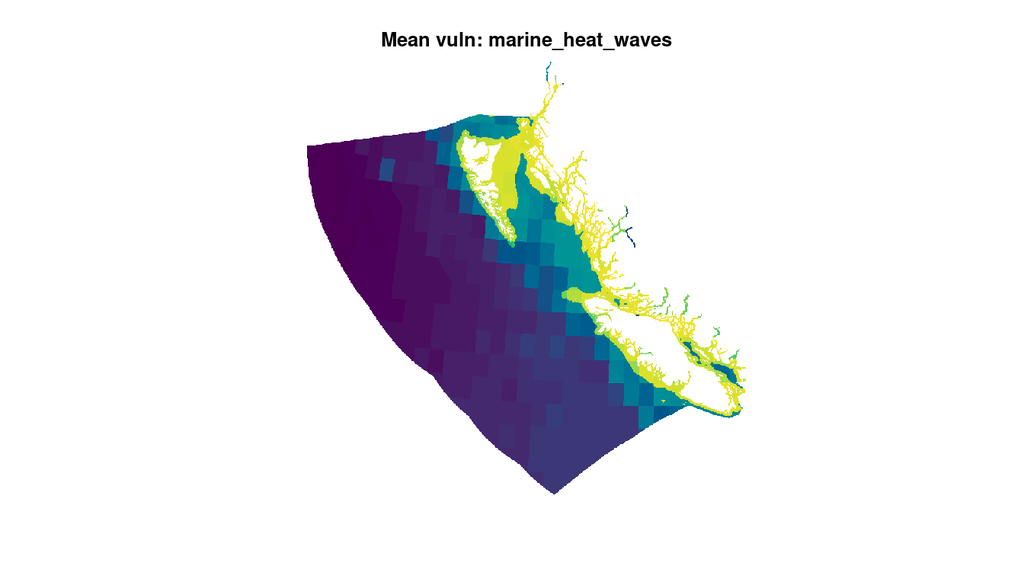

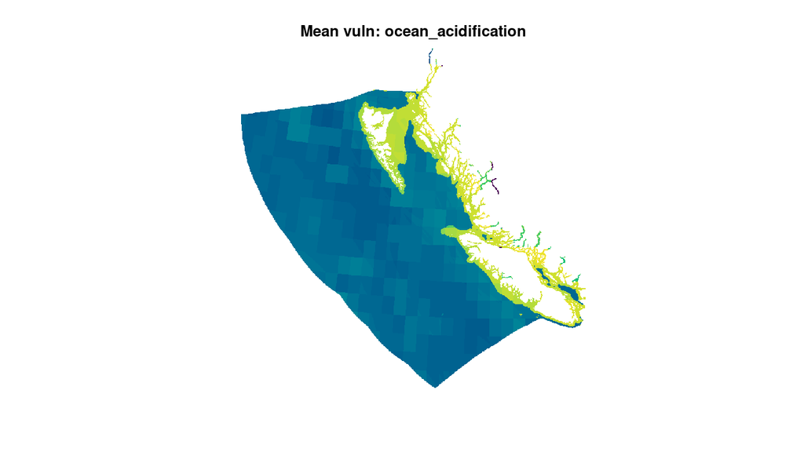

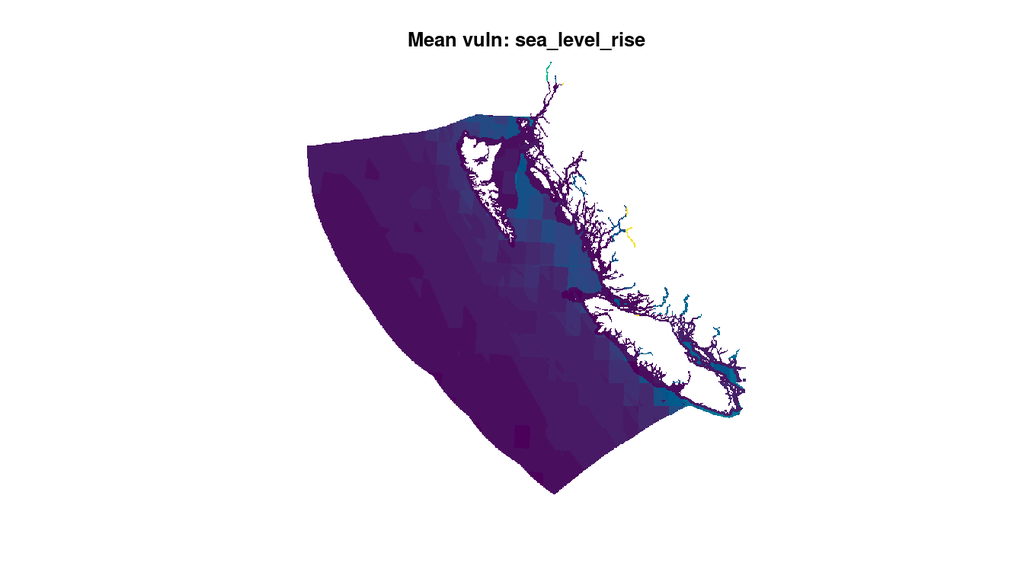

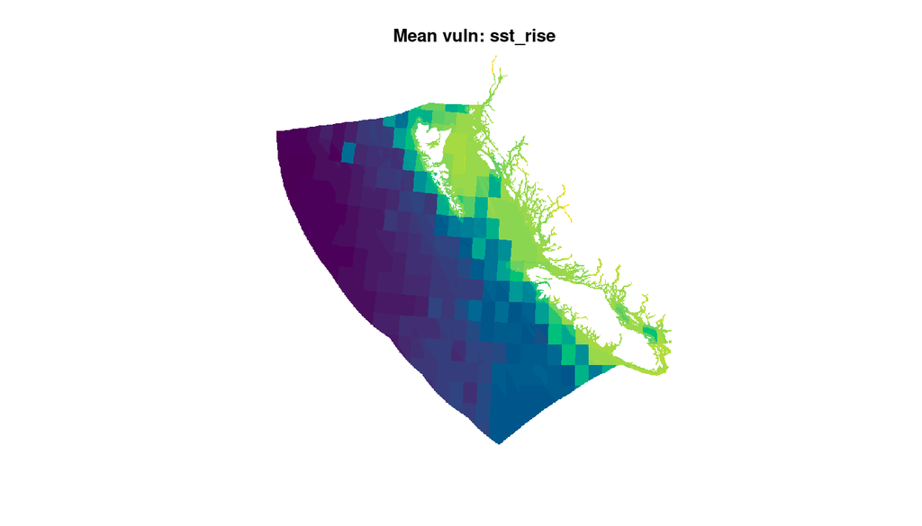

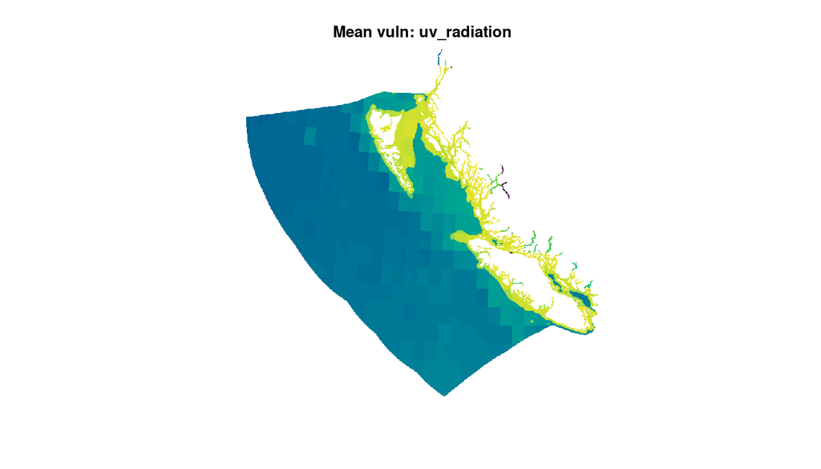

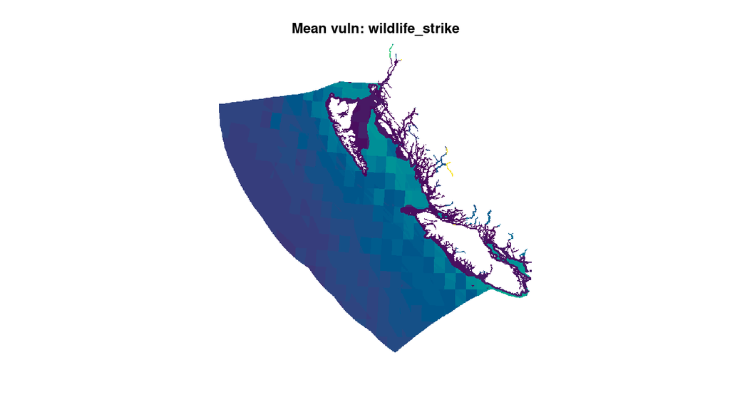

```r
vuln_spp_dir <- here_anx('_output/vuln_maps/vuln_maps_by_species')
mean_fs <- list.files(vuln_spp_dir, pattern = '_mean.tif', full.names = TRUE)
# sdev_fs <- list.files(vuln_spp_dir, pattern = '_sdev.tif', full.names = TRUE)

# focal_strs <- c('biomass_removal', 'bycatch',
#                 'microplastic', 'wildlife_strike',
#                 'nutrient_pollution', 'ocean_acidification',
#                 'sst_rise', 'marine_heat_wave',
#                 'light_pollution')
focal_strs <- basename(mean_fs) %>%
  str_remove_all('vuln_spp_|_mean.tif')

for(f in focal_strs) { ### f <- focal_strs[15]
  mean_f <- mean_fs[str_detect(basename(mean_fs), f)]
  # sdev_f <- sdev_fs[str_detect(basename(sdev_fs), f)]
  mean_rast <- terra::rast(mean_f)
  # sdev_rast <- terra::rast(sdev_f)

  map_cols <- hcl.colors(n = 50)

  plot(mean_rast, zlim = c(0, 1), col = map_cols, main = paste0('Mean vuln: ', f),
       legend = FALSE, axes = FALSE)
}
```

```r
tx_map_dir <- here_anx('vuln_maps_by_taxon/vuln_by_species')
mean_fs <- list.files(tx_map_dir, pattern = '_mean.tif', full.names = TRUE)
# sdev_fs <- list.files(vuln_spp_dir, pattern = '_sdev.tif', full.names = TRUE)
focal_tx <- 'fish'
mean_fs <- mean_fs[str_detect(basename(mean_fs), focal_tx)]

for(f in mean_fs) { ### f <- mean_fs[1]
  # sdev_f <- sdev_fs[str_detect(basename(sdev_fs), f)]
  mean_rast <- terra::rast(f)
  # sdev_rast <- terra::rast(sdev_f)

  map_cols <- hcl.colors(n = 50)

  plot(mean_rast, zlim = c(0, 1), col = map_cols, main = paste0('Mean vuln: ', basename(f)),
       legend = FALSE, axes = FALSE)
}
```

[output not shown]